# Larriet's Notebook_EasyVisa

# **Data Pre-processing**

- Missing value treatment (if needed)
- Feature engineering (if needed)
- Outlier detection and treatment (if needed)
- Preparing data for modeling
- Any other preprocessing steps (if needed)

```python
data["case_status"] = data["case_status"].apply(lambda x: 1 if x == "Certified" else 0)
data.head()
```

|  | continent | education_of_employee | has_job_experience | requires_job_training | no_of_employees | yr_of_estab | region_of_employment | prevailing_wage | unit_of_wage | full_time_position | case_status |
| --- | --- | --- | --- | --- | --- | --- | --- | --- | --- | --- | --- |
| 0 | Asia | High School | N | N | 14513 | 2007 | West | 592.2029 | Hour | Y | 0 |
| 1 | Asia | Master's | Y | N | 2412 | 2002 | Northeast | 83425.6500 | Year | Y | 1 |
| 2 | Asia | Bachelor's | N | Y | 44444 | 2008 | West | 122996.8600 | Year | Y | 0 |
| 3 | Asia | Bachelor's | N | N | 98 | 1897 | West | 83434.0300 | Year | Y | 0 |
| 4 | Africa | Master's | Y | N | 1082 | 2005 | South | 149907.3900 | Year | Y | 1 |

```python
X = data.drop(["case_status"], axis=1)
y = data["case_status"]

X = pd.get_dummies(X, drop_first=True)

X_train, X_test, y_train, y_test = train_test_split(X, y, test_size=0.3, random_state=1, stratify=y)
```

```python
print("Shape of Training set : ", X_train.shape)
print("Shape of test set : ", X_test.shape)
print("Percentage of classes in training set:")
print(y_train.value_counts(normalize=True))
print("Percentage of classes in test set:")
print(y_test.value_counts(normalize=True))
```

```
Shape of Training set :  (17836, 21)
Shape of test set :  (7644, 21)
Percentage of classes in training set:
case_status
1    0.667919
0    0.332081
Name: proportion, dtype: float64
Percentage of classes in test set:
case_status
1    0.667844
0    0.332156
Name: proportion, dtype: float64
```

```python
print("Training set shape:")
print("X_train shape:", X_train.shape)
print("y_train shape:", y_train.shape)

print("\nTesting set shape:")
print("X_test shape:", X_test.shape)
print("y_test shape:", y_test.shape)

total_samples = len(X_train) + len(X_test)
train_percentage = (len(X_train) / total_samples) * 100
test_percentage = (len(X_test) / total_samples) * 100

print("\nPercentage of Training set:", train_percentage, "%")
print("Percentage of Test set:", test_percentage, "%")
```

```
Training set shape:
X_train shape: (17836, 21)
y_train shape: (17836,)

Testing set shape:
X_test shape: (7644, 21)
y_test shape: (7644,)

Percentage of Training set: 70.0 %
Percentage of Test set: 30.0 %
```

# **Model Building**

```python
def model_performance_classification_sklearn(model, predictors, target):
    """
    Function to compute different metrics to check classification model performance

    model: classifier
    predictors: independent variables
    target: dependent variable
    """

    pred = model.predict(predictors)

    acc = accuracy_score(target, pred)
    recall = recall_score(target, pred)
    precision = precision_score(target, pred)
    f1 = f1_score(target, pred)

    df_perf = pd.DataFrame(
        {"Accuracy": acc, "Recall": recall, "Precision": precision, "F1": f1,},
        index=[0],
    )

    return df_perf
```

```python
def confusion_matrix_sklearn(model, predictors, target):
    """
    To plot the confusion_matrix with percentages

    model: classifier
    predictors: independent variables
    target: dependent variable
    """
    y_pred = model.predict(predictors)
    cm = confusion_matrix(target, y_pred)
    labels = np.asarray(
        [
            ["{0:0.0f}".format(item) + "\n{0:.2%}".format(item / cm.flatten().sum())]
            for item in cm.flatten()
        ]
    ).reshape(2, 2)

    plt.figure(figsize=(6, 4))
    sns.heatmap(cm, annot=labels, fmt="")
    plt.ylabel("True label")
    plt.xlabel("Predicted label")
```

# **Model Performance Improvement**

## **Note**

1. Sample parameter grids have been provided to do necessary hyperparameter tuning. These sample grids are expected to provide a balance between model performance improvement and execution time. One can extend/reduce the parameter grid based on execution time and system configuration.
- Please note that if the parameter grid is extended to improve the model performance further, the execution time will increase
2. The models chosen in this notebook are based on test runs. One can update the best models as obtained upon code execution and tune them for best performance.
- For Gradient Boosting:

```
param_grid = {
    "init": [AdaBoostClassifier(random_state=1),DecisionTreeClassifier(random_state=1)],
    "n_estimators": np.arange(50,110,25),
    "learning_rate": [0.01,0.1,0.05],
    "subsample":[0.7,0.9],
    "max_features":[0.5,0.7,1],
}
```

- For Adaboost:

```
param_grid = {
    "n_estimators": np.arange(50,110,25),
    "learning_rate": [0.01,0.1,0.05],
    "base_estimator": [
        DecisionTreeClassifier(max_depth=2, random_state=1),
        DecisionTreeClassifier(max_depth=3, random_state=1),
    ],
}
```

- For Bagging Classifier:

```
param_grid = {
    'max_samples': [0.8,0.9,1],
    'max_features': [0.7,0.8,0.9],
    'n_estimators' : [30,50,70],
}
```

- For Random Forest:

```
param_grid = {
    "n_estimators": [50,110,25],
    "min_samples_leaf": np.arange(1, 4),
    "max_features": [np.arange(0.3, 0.6, 0.1),'sqrt'],
    "max_samples": np.arange(0.4, 0.7, 0.1)
}
```

- For Decision Trees:

```
param_grid = {
    'max_depth': np.arange(2,6),
    'min_samples_leaf': [1, 4, 7],
    'max_leaf_nodes' : [10, 15],
    'min_impurity_decrease': [0.0001,0.001]
}
```

- For XGBoost:

```
param_grid={'n_estimators':np.arange(50,110,25),
            'scale_pos_weight':[1,2,5],
            'learning_rate':[0.01,0.1,0.05],
            'gamma':[1,3],
            'subsample':[0.7,0.9]
}
```

```python
from sklearn.model_selection import train_test_split
from sklearn.ensemble import RandomForestClassifier
from sklearn.metrics import accuracy_score, classification_report

rf_estimator = RandomForestClassifier(class_weight="balanced", random_state=1)
rf_estimator.fit(X_train, y_train)
```

```
RandomForestClassifier(class_weight='balanced', random_state=1)
```

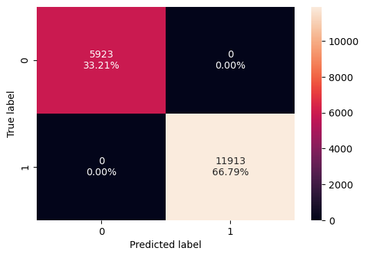

```python
confusion_matrix_sklearn(rf_estimator,X_train,y_train)
```

```python
y_pred1 = rf_estimator.predict(X_train)

print("Accuracy:", accuracy_score(y_train, y_pred1))
print("Classification Report:\n", classification_report(y_train, y_pred1))
```

```
Accuracy: 1.0
Classification Report:
               precision    recall  f1-score   support

           0       1.00      1.00      1.00      5923
           1       1.00      1.00      1.00     11913

    accuracy                           1.00     17836
   macro avg       1.00      1.00      1.00     17836
weighted avg       1.00      1.00      1.00     17836
```

```python
rf_estimator_model_train_perf = model_performance_classification_sklearn(rf_estimator,X_train,y_train)
rf_estimator_model_train_perf
```

|  | Accuracy | Recall | Precision | F1 |
| --- | --- | --- | --- | --- |
| 0 | 1.0 | 1.0 | 1.0 | 1.0 |

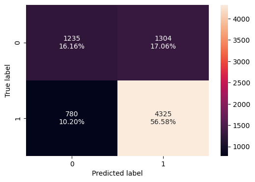

```python
confusion_matrix_sklearn(rf_estimator,X_test,y_test)
```

```python
y_pred = rf_estimator.predict(X_test)

print("Accuracy:", accuracy_score(y_test, y_pred))
print("Classification Report:\n", classification_report(y_test, y_pred))
```

```
Accuracy: 0.727367870225013
Classification Report:
               precision    recall  f1-score   support

           0       0.61      0.49      0.54      2539
           1       0.77      0.85      0.81      5105

    accuracy                           0.73      7644
   macro avg       0.69      0.67      0.67      7644
weighted avg       0.72      0.73      0.72      7644
```

```python
rf_estimator_model_test_perf = model_performance_classification_sklearn(rf_estimator,X_test,y_test)
rf_estimator_model_test_perf
```

|  | Accuracy | Recall | Precision | F1 |
| --- | --- | --- | --- | --- |
| 0 | 0.727368 | 0.847209 | 0.768343 | 0.805851 |

```python
The model appears to be performing well on the train set with near perfect accuracy, precision, recall,
and F1-score for both classes although it is not generalizing well on the test set. Further tuning may be required to
improve model performance.
```

```python
rf_tuned = RandomForestClassifier(random_state=1, oob_score=True, bootstrap=True)

parameters = {
    "max_depth": list(np.arange(5, 15, 5)),
    "max_features": ["sqrt", "log2"],
    "min_samples_split": [3, 5, 7],
    "n_estimators": np.arange(10, 40, 10),
}

acc_scorer = metrics.make_scorer(metrics.f1_score)

grid_obj = GridSearchCV(rf_tuned, parameters, scoring=acc_scorer, cv=5, n_jobs=-1)
grid_obj = grid_obj.fit(X_train, y_train)

rf_tuned = grid_obj.best_estimator_

rf_tuned.fit(X_train, y_train)
```

[output not shown]

[output cut: 65 more lines]

[output not shown]

```
RandomForestClassifier(max_depth=10, min_samples_split=7, n_estimators=20,
                       oob_score=True, random_state=1)
```

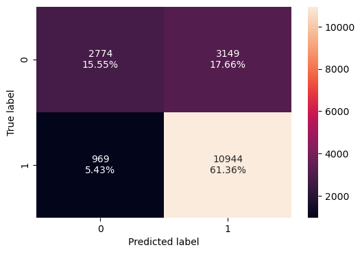

```python
confusion_matrix_sklearn(rf_tuned,X_train,y_train)
```

```python
y_pred1 = rf_tuned.predict(X_train)

print("Accuracy:", accuracy_score(y_train, y_pred1))
print("Classification Report:\n", classification_report(y_train, y_pred1))
```

```
Accuracy: 0.7691186364655752
Classification Report:
               precision    recall  f1-score   support

           0       0.74      0.47      0.57      5923
           1       0.78      0.92      0.84     11913

    accuracy                           0.77     17836
   macro avg       0.76      0.69      0.71     17836
weighted avg       0.76      0.77      0.75     17836
```

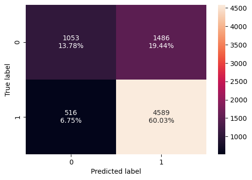

```python
confusion_matrix_sklearn(rf_tuned,X_test,y_test)
```

```python
y_pred = rf_tuned.predict(X_test)

print("Accuracy:", accuracy_score(y_test, y_pred))
print("Classification Report:\n", classification_report(y_test, y_pred))
```

```
Accuracy: 0.7380952380952381
Classification Report:
               precision    recall  f1-score   support

           0       0.67      0.41      0.51      2539
           1       0.76      0.90      0.82      5105

    accuracy                           0.74      7644
   macro avg       0.71      0.66      0.67      7644
weighted avg       0.73      0.74      0.72      7644
```

```python
rf_tuned_model_train_perf = model_performance_classification_sklearn(rf_tuned,X_train,y_train)
rf_tuned_model_train_perf
```

|  | Accuracy | Recall | Precision | F1 |
| --- | --- | --- | --- | --- |
| 0 | 0.769119 | 0.91866 | 0.776556 | 0.841652 |

```python
rf_tuned_model_test_perf = model_performance_classification_sklearn(rf_tuned,X_test,y_test)
rf_tuned_model_test_perf
```

|  | Accuracy | Recall | Precision | F1 |
| --- | --- | --- | --- | --- |
| 0 | 0.738095 | 0.898923 | 0.755391 | 0.82093 |

```python
We have an F1 score of 0.84 and 0.82 on the training and test data
After hyperparameter tuning the model performance has generalized
The model has a high recall along with a good precision
```

```python
dtree = DecisionTreeClassifier(random_state=1)
dtree.fit(X_train, y_train)
```

```
DecisionTreeClassifier(random_state=1)
```

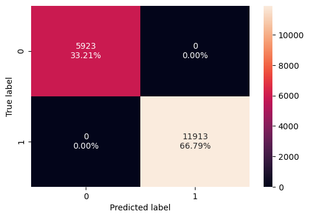

```python
confusion_matrix_sklearn(dtree, X_train, y_train)
```

```python
y_pred1 = dtree.predict(X_train)

print("Accuracy:", accuracy_score(y_train, y_pred1))
print("Classification Report:\n", classification_report(y_train, y_pred1))
```

```
Accuracy: 1.0
Classification Report:
               precision    recall  f1-score   support

           0       1.00      1.00      1.00      5923
           1       1.00      1.00      1.00     11913

    accuracy                           1.00     17836
   macro avg       1.00      1.00      1.00     17836
weighted avg       1.00      1.00      1.00     17836
```

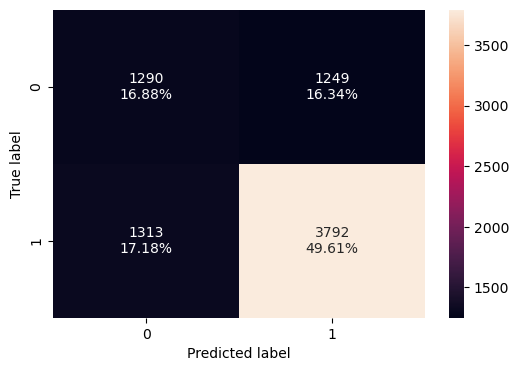

```python
confusion_matrix_sklearn(dtree, X_test, y_test)
```

```python
y_pred = dtree.predict(X_test)

print("Accuracy:", accuracy_score(y_test, y_pred))
print("Classification Report:\n", classification_report(y_test, y_pred))
```

```
Accuracy: 0.6648351648351648
Classification Report:
               precision    recall  f1-score   support

           0       0.50      0.51      0.50      2539
           1       0.75      0.74      0.75      5105

    accuracy                           0.66      7644
   macro avg       0.62      0.63      0.62      7644
weighted avg       0.67      0.66      0.67      7644
```

```python
decision_tree_perf_train = model_performance_classification_sklearn(dtree, X_train, y_train)
decision_tree_perf_train
```

|  | Accuracy | Recall | Precision | F1 |
| --- | --- | --- | --- | --- |
| 0 | 1.0 | 1.0 | 1.0 | 1.0 |

```python
decision_tree_perf_test = model_performance_classification_sklearn(dtree, X_test, y_test)
decision_tree_perf_test
```

|  | Accuracy | Recall | Precision | F1 |
| --- | --- | --- | --- | --- |
| 0 | 0.664835 | 0.742801 | 0.752232 | 0.747487 |

```python
There might be a overfitting issue because the performance on the training set is significantly better than on the test set
```

```python
dtree_estimator = DecisionTreeClassifier(class_weight="balanced", random_state=1)

parameters = {
    "max_depth": np.arange(10, 30, 5),
    "min_samples_leaf": [3, 5, 7],
    "max_leaf_nodes": [2, 3, 5],
    "min_impurity_decrease": [0.0001, 0.001],
}

scorer = metrics.make_scorer(metrics.f1_score)

grid_obj = GridSearchCV(dtree_estimator, parameters, scoring=scorer, n_jobs=-1)

grid_obj = grid_obj.fit(X_train, y_train)

dtree_estimator = grid_obj.best_estimator_

dtree_estimator.fit(X_train, y_train)
```

```
DecisionTreeClassifier(class_weight='balanced', max_depth=10, max_leaf_nodes=2,
                       min_impurity_decrease=0.0001, min_samples_leaf=3,
                       random_state=1)
```

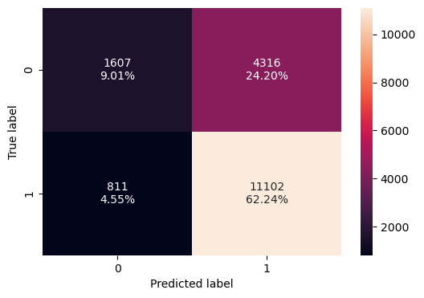

```python
confusion_matrix_sklearn(dtree_estimator, X_train,y_train)
```

```python
y_pred1 = dtree_estimator.predict(X_train)

print("Accuracy:", accuracy_score(y_train, y_pred1))
print("Classification Report:\n", classification_report(y_train, y_pred1))
```

```
Accuracy: 0.7125476564252075
Classification Report:
               precision    recall  f1-score   support

           0       0.66      0.27      0.39      5923
           1       0.72      0.93      0.81     11913

    accuracy                           0.71     17836
   macro avg       0.69      0.60      0.60     17836
weighted avg       0.70      0.71      0.67     17836
```

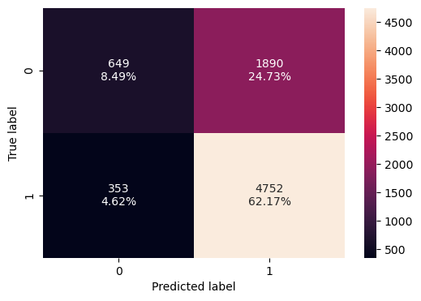

```python
confusion_matrix_sklearn(dtree_estimator, X_test,y_test)
```